# Project Python Foundations: FoodHub Data Analysis

**Marks: 40**

### Context

The number of restaurants in New York is increasing day by day. Lots of students and busy professionals rely on those restaurants due to their hectic lifestyles. Online food delivery service is a great option for them. It provides them with good food from their favorite restaurants. A food aggregator company FoodHub offers access to multiple restaurants through a single smartphone app.

The app allows the restaurants to receive a direct online order from a customer. The app assigns a delivery person from the company to pick up the order after it is confirmed by the restaurant. The delivery person then uses the map to reach the restaurant and waits for the food package. Once the food package is handed over to the delivery person, he/she confirms the pick-up in the app and travels to the customer's location to deliver the food. The delivery person confirms the drop-off in the app after delivering the food package to the customer. The customer can rate the order in the app. The food aggregator earns money by collecting a fixed margin of the delivery order from the restaurants.

### Objective

The food aggregator company has stored the data of the different orders made by the registered customers in their online portal. They want to analyze the data to get a fair idea about the demand of different restaurants which will help them in enhancing their customer experience. Suppose you are hired as a Data Scientist in this company and the Data Science team has shared some of the key questions that need to be answered. Perform the data analysis to find answers to these questions that will help the company to improve the business.

### Data Description

The data contains the different data related to a food order. The detailed data dictionary is given below.

### Data Dictionary

- order_id: Unique ID of the order
- customer_id: ID of the customer who ordered the food
- restaurant_name: Name of the restaurant
- cuisine_type: Cuisine ordered by the customer
- cost: Cost of the order
- day_of_the_week: Indicates whether the order is placed on a weekday or weekend (The weekday is from Monday to Friday and the weekend is Saturday and Sunday)
- rating: Rating given by the customer out of 5
- food_preparation_time: Time (in minutes) taken by the restaurant to prepare the food. This is calculated by taking the difference between the timestamps of the restaurant's order confirmation and the delivery person's pick-up confirmation.
- delivery_time: Time (in minutes) taken by the delivery person to deliver the food package. This is calculated by taking the difference between the timestamps of the delivery person's pick-up confirmation and drop-off information

# John D. Noble Food Hub Project - August 2021

### John's Standard Libraries

```python
import sys

!"{sys.executable}" -m pip install -U pandas-profiling[notebook]
!jupyter nbextension enable --py widgetsnbextension
```

```
zsh:1: no matches found: pandas-profiling[notebook]
Enabling notebook extension jupyter-js-widgets/extension...
      - Validating: OK
```

```python
# Standard Library Imports
from pathlib import Path

# Installed packages
import pandas as pd
import seaborn as sns
sns.set(color_codes=True) # adds a nice background to the graphs
import matplotlib.pyplot as plt
%matplotlib inline
from ipywidgets import widgets

# Detailed Profiling Widget
from pandas_profiling import ProfileReport
from pandas_profiling.utils.cache import cache_file

import warnings
warnings.filterwarnings('ignore')
```

```python
#IGNORE
#TO ADD DETAILED REPORT RUN AS TWO LINES; AFTER DATA READ
#profile = ProfileReport(df, title="Adult Data", html={"style": {"full_width": True}}, sort=None)
#profile.to_widgets()
```

### Understanding the structure of the data

```python
# read the data
df = pd.read_csv('foodhub_order.csv')
# returns the first 5 rows
df.head()
```

|  | order_id | customer_id | restaurant_name | cuisine_type | cost_of_the_order | day_of_the_week | rating | food_preparation_time | delivery_time |
| --- | --- | --- | --- | --- | --- | --- | --- | --- | --- |
| 0 | 1477147 | 337525 | Hangawi | Korean | 30.75 | Weekend | Not given | 25 | 20 |
| 1 | 1477685 | 358141 | Blue Ribbon Sushi Izakaya | Japanese | 12.08 | Weekend | Not given | 25 | 23 |
| 2 | 1477070 | 66393 | Cafe Habana | Mexican | 12.23 | Weekday | 5 | 23 | 28 |
| 3 | 1477334 | 106968 | Blue Ribbon Fried Chicken | American | 29.20 | Weekend | 3 | 25 | 15 |
| 4 | 1478249 | 76942 | Dirty Bird to Go | American | 11.59 | Weekday | 4 | 25 | 24 |

#### Observations:

The DataFrame has 9 variables as mentioned in the Data Dictionary. Data in each row corresponds to the order placed by a customer.

### **Question 1:** Write the code to check the shape of the dataset and write your observations based on that. (0.5 mark)

```python
#check the shape of the dataset
df.shape
```

```
(1898, 9)
```

#### Observations:

The DataFrame has 1898 rows representing the orders placed by the customer.

### Question 2: Write the observations based on the below output from the info() method. (0.5 mark)

```python
# use info() to print a concise summary of the DataFrame
df.info()
```

```
<class 'pandas.core.frame.DataFrame'>
RangeIndex: 1898 entries, 0 to 1897
Data columns (total 9 columns):
 #   Column                 Non-Null Count  Dtype
---  ------                 --------------  -----
 0   order_id               1898 non-null   int64
 1   customer_id            1898 non-null   int64
 2   restaurant_name        1898 non-null   object
 3   cuisine_type           1898 non-null   object
 4   cost_of_the_order      1898 non-null   float64
 5   day_of_the_week        1898 non-null   object
 6   rating                 1898 non-null   object
 7   food_preparation_time  1898 non-null   int64
 8   delivery_time          1898 non-null   int64
dtypes: float64(1), int64(4), object(4)
memory usage: 133.6+ KB
```

```python
#check to see if any data is missing.
df.isnull().sum()
```

```
order_id                 0
customer_id              0
restaurant_name          0
cuisine_type             0
cost_of_the_order        0
day_of_the_week          0
rating                   0
food_preparation_time    0
delivery_time            0
dtype: int64
```

```python
#useful to get all the column headings for future analaysis.
print (df.columns);
```

```
Index(['order_id', 'customer_id', 'restaurant_name', 'cuisine_type',
       'cost_of_the_order', 'day_of_the_week', 'rating',
       'food_preparation_time', 'delivery_time'],
      dtype='object')
```

#### Observations:

As the data is presented, before any adjustments to Dtype:

1) 5 of the 9 columns are Numeric Data Types - 'order_id', 'customer_id', 'cost_of_the_order', 'food_preparation_time', 'delivery_time'

```
1.1) 4 are integers
1.2) 1 is a floating point with a 'decimal'
```

2) 4 of the 9 columns are string type - 'restaurant_name', 'cuisine_type','day_of_the_week', 'rating',

3) There is no missing data in the DataFrame.

### Question 3: 'restaurant_name', 'cuisine_type', 'day_of_the_week' are object types. Write the code to convert the mentioned features to 'category' and write your observations on the same. (0.5 mark)

```python
# coverting "objects" to "category" reduces the data space required to store the dataframe
# write the code to convert 'restaurant_name', 'cuisine_type', 'day_of_the_week' into categorical data

# use info() to print a concise summary of the DataFrame
df.info()
```

```
<class 'pandas.core.frame.DataFrame'>
RangeIndex: 1898 entries, 0 to 1897
Data columns (total 9 columns):
 #   Column                 Non-Null Count  Dtype
---  ------                 --------------  -----
 0   order_id               1898 non-null   int64
 1   customer_id            1898 non-null   int64
 2   restaurant_name        1898 non-null   object
 3   cuisine_type           1898 non-null   object
 4   cost_of_the_order      1898 non-null   float64
 5   day_of_the_week        1898 non-null   object
 6   rating                 1898 non-null   object
 7   food_preparation_time  1898 non-null   int64
 8   delivery_time          1898 non-null   int64
dtypes: float64(1), int64(4), object(4)
memory usage: 133.6+ KB
```

```python
#changethe three "objects" to "category"
df['restaurant_name'] = df.restaurant_name.astype('category')
df['cuisine_type'] = df.cuisine_type.astype('category')
df['day_of_the_week'] = df.day_of_the_week.astype('category')
```

```python
# Recheck to make sure the data type conversion was successful.
df.info()
```

```
<class 'pandas.core.frame.DataFrame'>
RangeIndex: 1898 entries, 0 to 1897
Data columns (total 9 columns):
 #   Column                 Non-Null Count  Dtype
---  ------                 --------------  -----
 0   order_id               1898 non-null   int64
 1   customer_id            1898 non-null   int64
 2   restaurant_name        1898 non-null   category
 3   cuisine_type           1898 non-null   category
 4   cost_of_the_order      1898 non-null   float64
 5   day_of_the_week        1898 non-null   category
 6   rating                 1898 non-null   object
 7   food_preparation_time  1898 non-null   int64
 8   delivery_time          1898 non-null   int64
dtypes: category(3), float64(1), int64(4), object(1)
memory usage: 102.7+ KB
```

#### Observations:

The the 3 adjustments to Dtype:

1) There are 5 numerical columns, 3 categorical columns and 1 object.

2) The overall memory used decreased.

**Note: further into the anlaysis 'rating' Dtype is also changed to answer another question.

### **Question 4:** Write the code to find the summary statistics and write your observations based on that. (1 mark)

```python
# This code returns the summary stats for both numerical and non-numerical (include='all')

df.describe(include='all').T
```

|  | count | unique | top | freq | mean | std | min | 25% | 50% | 75% | max |
| --- | --- | --- | --- | --- | --- | --- | --- | --- | --- | --- | --- |
| order_id | 1898.0 | NaN | NaN | NaN | 1477495.5 | 548.049724 | 1476547.0 | 1477021.25 | 1477495.5 | 1477969.75 | 1478444.0 |
| customer_id | 1898.0 | NaN | NaN | NaN | 171168.478398 | 113698.139743 | 1311.0 | 77787.75 | 128600.0 | 270525.0 | 405334.0 |
| restaurant_name | 1898 | 178 | Shake Shack | 219 | NaN | NaN | NaN | NaN | NaN | NaN | NaN |
| cuisine_type | 1898 | 14 | American | 584 | NaN | NaN | NaN | NaN | NaN | NaN | NaN |
| cost_of_the_order | 1898.0 | NaN | NaN | NaN | 16.498851 | 7.483812 | 4.47 | 12.08 | 14.14 | 22.2975 | 35.41 |
| day_of_the_week | 1898 | 2 | Weekend | 1351 | NaN | NaN | NaN | NaN | NaN | NaN | NaN |
| rating | 1898 | 4 | Not given | 736 | NaN | NaN | NaN | NaN | NaN | NaN | NaN |
| food_preparation_time | 1898.0 | NaN | NaN | NaN | 27.37197 | 4.632481 | 20.0 | 23.0 | 27.0 | 31.0 | 35.0 |
| delivery_time | 1898.0 | NaN | NaN | NaN | 24.161749 | 4.972637 | 15.0 | 20.0 | 25.0 | 28.0 | 33.0 |

## Observations:

Of the 1898 orders in this data set:

- American food is the most often selected "cuisine' type.
- Shake Shake is the most requested resturant.
- The avg total time from customer order to recipt is just under an hour.

  ```
    - The average prep time is ~27 mins (27.37197).
    - The average time to recieve an order is ~24mins (24.161749).
  ```

- The average cost per order is $16.50.
- A large number of the orders are not given ratings.
- Both 'order_id' and 'customer_id' offer little information as they are assigned; the notable exception being 'customer_id' that show up more than once, representing repeat customers ordering.

### **Question 5:** How many orders are not rated? (0.5 mark)

```python
# There are 736 orders with no rating; See above Q4 code and summery data for "ratings"

# Method #2
df['rating'].value_counts(sort= True,ascending = False)
```

```
Not given    736
5            588
4            386
3            188
Name: rating, dtype: int64
```

#### Observations:

There were 736 out of a total of 1898 orders that had no rating ('Not given')

### Exploratory Data Analysis (EDA)

## Univariate Analysis

### **Question 6:** Explore all the variables and provide observations on the distributions of all the relevant variables in the dataset. (5 marks)

```python
df.head()
```

|  | order_id | customer_id | restaurant_name | cuisine_type | cost_of_the_order | day_of_the_week | rating | food_preparation_time | delivery_time |
| --- | --- | --- | --- | --- | --- | --- | --- | --- | --- |
| 0 | 1477147 | 337525 | Hangawi | Korean | 30.75 | Weekend | Not given | 25 | 20 |
| 1 | 1477685 | 358141 | Blue Ribbon Sushi Izakaya | Japanese | 12.08 | Weekend | Not given | 25 | 23 |
| 2 | 1477070 | 66393 | Cafe Habana | Mexican | 12.23 | Weekday | 5 | 23 | 28 |
| 3 | 1477334 | 106968 | Blue Ribbon Fried Chicken | American | 29.20 | Weekend | 3 | 25 | 15 |
| 4 | 1478249 | 76942 | Dirty Bird to Go | American | 11.59 | Weekday | 4 | 25 | 24 |

```python
df.describe()
```

|  | order_id | customer_id | cost_of_the_order | food_preparation_time | delivery_time |
| --- | --- | --- | --- | --- | --- |
| count | 1.898000e+03 | 1898.000000 | 1898.000000 | 1898.000000 | 1898.000000 |
| mean | 1.477496e+06 | 171168.478398 | 16.498851 | 27.371970 | 24.161749 |
| std | 5.480497e+02 | 113698.139743 | 7.483812 | 4.632481 | 4.972637 |
| min | 1.476547e+06 | 1311.000000 | 4.470000 | 20.000000 | 15.000000 |
| 25% | 1.477021e+06 | 77787.750000 | 12.080000 | 23.000000 | 20.000000 |
| 50% | 1.477496e+06 | 128600.000000 | 14.140000 | 27.000000 | 25.000000 |
| 75% | 1.477970e+06 | 270525.000000 | 22.297500 | 31.000000 | 28.000000 |
| max | 1.478444e+06 | 405334.000000 | 35.410000 | 35.000000 | 33.000000 |

### Numerical Values - Central Tendancy & Dispersion

```python
# 1) Defined a function that will create a boxplot and histogram for numerical variables.
# 2) This function takes the numerical column as the input and returns the boxplots and
#    histograms for the variable.along the same scale.
```

```python
def histogram_boxplot(data, feature, figsize=(12, 7), kde=False, bins=None):
    """
    Boxplot and histogram combined

    data: dataframe
    feature: dataframe column
    figsize: size of figure (default (12,7))
    kde: whether to show the density curve (default False)
    bins: number of bins for histogram (default None)
    """
    f2, (ax_box2, ax_hist2) = plt.subplots(
        nrows=2,  # Number of rows of the subplot grid= 2
        sharex=True,  # x-axis will be shared among all subplots
        gridspec_kw={"height_ratios": (0.25, 0.75)},
        figsize=figsize,
    )  # creating the 2 subplots
    sns.boxplot(
        data=data, x=feature, ax=ax_box2, showmeans=True, color="#ebf5fb"
    )  # boxplot will be created and a star will indicate the mean value of the column
    sns.histplot(
        data=data, x=feature, kde=kde, ax=ax_hist2, bins=bins, palette="winter"
    ) if bins else sns.histplot(
        data=data, x=feature, kde=kde, ax=ax_hist2
    )  # For histogram
    ax_hist2.axvline(
        data[feature].mean(), color="green", linestyle="--"
    )  # Add mean to the histogram
    ax_hist2.axvline(
        data[feature].median(), color="black", linestyle="-"
    )  # Add median to the histogram
```

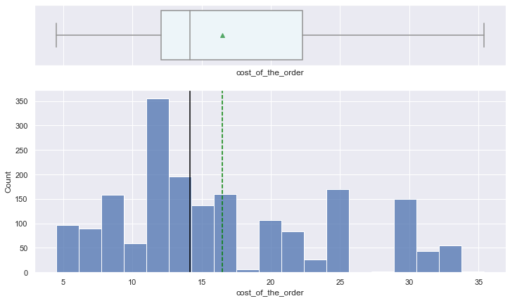

```python
histogram_boxplot(df, 'cost_of_the_order');
```

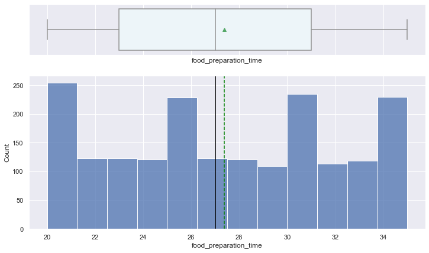

```python
histogram_boxplot(df, 'food_preparation_time');
```

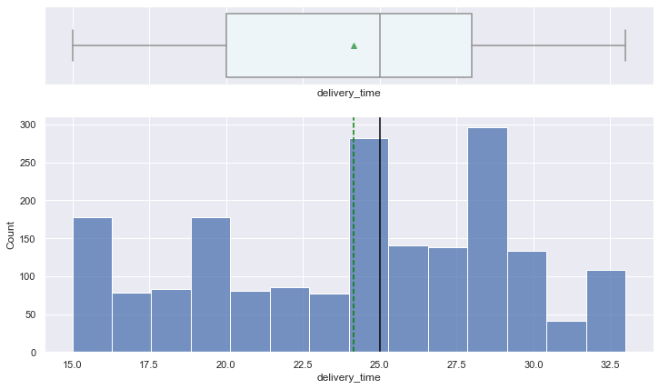

```python
histogram_boxplot(df, 'delivery_time');
```

### Categorical Values Exploration

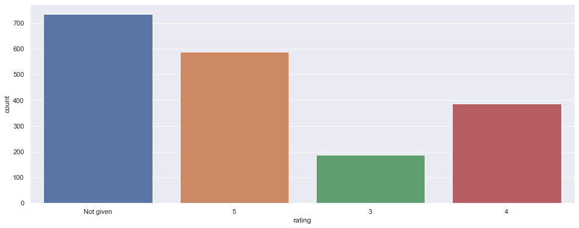

```python
# shows the counts of ratings given
plt.figure(figsize=(16, 6))
sns.countplot(df['rating']);
```

```python
df['restaurant_name'].nunique()
```

```
178
```

```python
df['restaurant_name'].value_counts(sort= True,ascending = False).head(15)
```

```
Shake Shack                      219
The Meatball Shop                132
Blue Ribbon Sushi                119
Blue Ribbon Fried Chicken         96
Parm                              68
RedFarm Broadway                  59
RedFarm Hudson                    55
TAO                               49
Han Dynasty                       46
Blue Ribbon Sushi Bar & Grill     44
Nobu Next Door                    42
Rubirosa                          37
Sushi of Gari 46                  37
Momoya                            30
Blue Ribbon Sushi Izakaya         29
Name: restaurant_name, dtype: int64
```

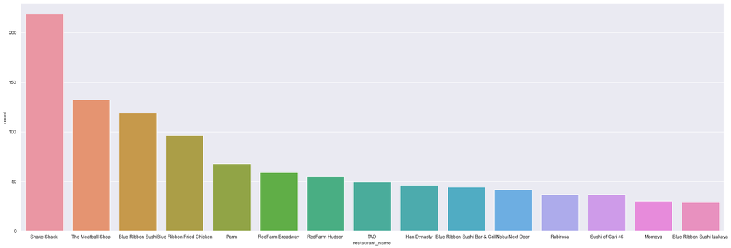

```python
#shows the "Top 15" Resturants by Name (to save space and read the lable names)
plt.figure(figsize=(30, 10))
sns.countplot(df['restaurant_name'],
    order=df['restaurant_name'].value_counts().iloc[:15].index)
```

```python
df['cuisine_type'].value_counts(sort= True,ascending = False)
```

```
American          584
Japanese          470
Italian           298
Chinese           215
Mexican            77
Indian             73
Middle Eastern     49
Mediterranean      46
Thai               19
French             18
Southern           17
Korean             13
Spanish            12
Vietnamese          7
Name: cuisine_type, dtype: int64
```

```python
df['cuisine_type'].nunique()
```

```
14
```

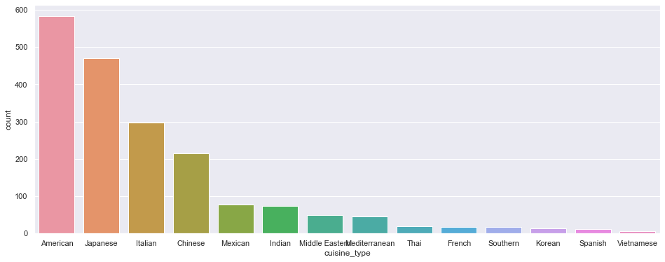

```python
#Shows the counts by "Cuisine Type"
#plt.figure(figsize=(16, 6))
#sns.countplot(df['cuisine_type']);

plt.figure(figsize=(16, 6))
sns.countplot(df['cuisine_type'],
    order=df['cuisine_type'].value_counts().index)
```

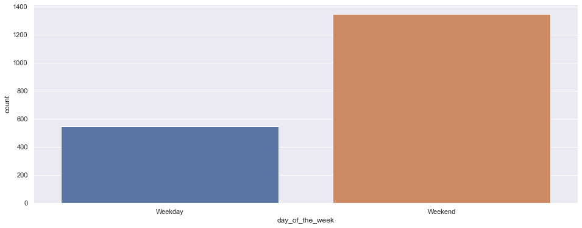

```python
#shows the count of orders durning the week vs the weekend.
plt.figure(figsize=(16, 6))
sns.countplot(df['day_of_the_week']);
```

```python
#This code will generate the count of days by type.
df['day_of_the_week'].value_counts()
```

```
Weekend    1351
Weekday     547
Name: day_of_the_week, dtype: int64
```

```python
# Total # of customers/orders - some customer have ordered multiple times.
df['customer_id'].count()
```

```
1898
```

```python
#This is the number of unique customers
df['customer_id'].nunique()
```

```
1200
```

```python
# Top Customers based on # of orders
df['customer_id'].value_counts(sort= True,ascending = False).head(10)
```

```
52832     13
47440     10
83287      9
250494     8
65009      7
259341     7
82041      7
276192     7
115213     6
97079      6
Name: customer_id, dtype: int64
```

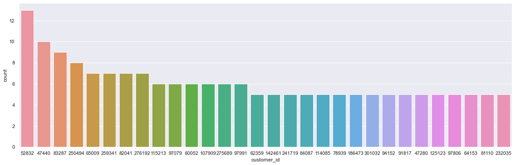

```python
# The Top 30 customer by unique id and how many orders they have.
plt.figure(figsize=(20, 6))
sns.countplot(df['customer_id'],
    order=df['customer_id'].value_counts().iloc[:30].index);
```

#### Observations:

Numerical Variables

- Both 'order_id' and 'customer_id' offer little information as they are assigned; the notable exception being 'customer_id' that show up more than once, representing repeat customers ordering.
- The 'cost_of_the_order' range is 4.47 to 35.41' with a mean of 16.50.

  ```
    - Minimum 4.47
    - 5-th percentile 6.07
    - Q1 12.08
    - median 14.14
    - Q3 22.2975
    - 95-th percentile 31.33
    - Maximum 35.41
    - Range 30.94
    - Interquartile range (IQR)10.2175
  ```

- The 'food_preparation_time' range is 20mins to 35mins with a mean of 27.37mins
- The 'delivery_time' range is 15min to 33mins with a mean of 24.16mins
  - Day_of_the_week is highly correlated with delivery_time

Categorical Variables

- For ratings "Not given" (or no rating) is the most frequent, followed by a rating =5, then 4, and lastly =3.
- There are 178 unique resturants represented in this data sample.
- There 14 distinct cuisine types in the data set
  - In order American, Japanese, Italian, and then Chinese are ordered most often
  - In the American category, Shake Shack is ordered most often
- Weekends are the busiest time for Foodhub

  ```
   -  Day_of_the_week is highly correlated with delivery_time
  ```

  Customers
- There are 1200 unique customers; some customers have used FoodHub mulitple times
- The most frequent repeat customer has order 13 times; the next is customer 47440 with 10 orders

### Question 7: Write the code to find the top 5 restaurants that have received the highest number of orders. (1 mark)

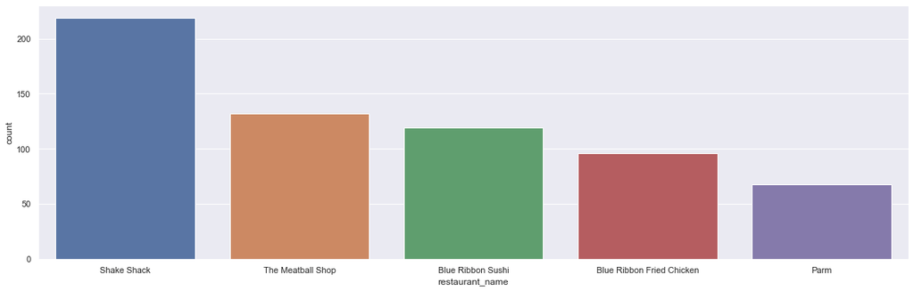

```python
#Shows the "Top 5" Resturants by Name
plt.figure(figsize=(20, 6))
sns.countplot(df['restaurant_name'],
    order=df['restaurant_name'].value_counts().iloc[:5].index);
```

```python
#Method 2
df['restaurant_name'].value_counts(sort= True,ascending = False).head(5)
```

```
Shake Shack                  219
The Meatball Shop            132
Blue Ribbon Sushi            119
Blue Ribbon Fried Chicken     96
Parm                          68
Name: restaurant_name, dtype: int64
```

#### Observations:

The Top 5 Resturants are:

1) Shake Shack  
2) The Meatball Shop  
3) Blue Ribbon Sushi  
4) Blue Ribbon Fried Chicken  
5) Parm

### Question 8: Write the code to find the most popular cuisine on weekends. (1 mark)

```python
df['cuisine_type'].value_counts()
```

```
American          584
Japanese          470
Italian           298
Chinese           215
Mexican            77
Indian             73
Middle Eastern     49
Mediterranean      46
Thai               19
French             18
Southern           17
Korean             13
Spanish            12
Vietnamese          7
Name: cuisine_type, dtype: int64
```

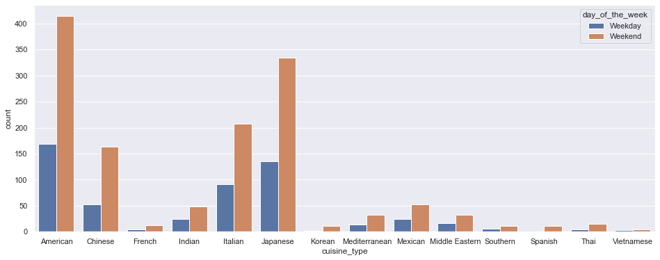

```python
# Easier to understand visually, this shows the counts on the weekend by cuisine type.
plt.figure(figsize=(16, 6))
sns.countplot(df['cuisine_type'], hue=df['day_of_the_week']);
```

#### Observations:

- Comparing weekdays to weekends by cuisine type, it is clear that American food is the most popular weekend order followed by Japanese and Italian.
- American and Japanese cost_of_the_order is higher than others.

### Question 9: Write the code to find the number of total orders where the cost is above 20 dollars. What is the percentage of such orders in the dataset? (1 mark)

```python
# How many order meet the condiiton where the total cost is above 20 dollars

df.value_counts(df["cost_of_the_order"]>20)
```

```
cost_of_the_order
False    1343
True      555
dtype: int64
```

```python
# How many order meet the condiiton where the total cost is above 20 dollars expressed as a percentage.
df.value_counts(df["cost_of_the_order"]>20) / df["cost_of_the_order"].count()
```

```
cost_of_the_order
False    0.707587
True     0.292413
dtype: float64
```

#### Observations:

- The number of orders > $20 is 29% of the total orders.

### Question 10: Write the code to find the mean delivery time based on this dataset. (1 mark)

```python
# This will calcualte both the mean of delievery time and food prepration time. Both will be needed later.

df_mean = df[["delivery_time", "food_preparation_time"]].mean()
print(df_mean)
```

```
delivery_time            24.161749
food_preparation_time    27.371970
dtype: float64
```

#### Observations:

- The mean delivery time is ~24mins (24.161749).
- Other Interesting Facts

  -The average total time from customer order to drop-off is just under an hour (~51 mins).

  -The average prep time is ~27 mins (27.37197).

### Question 11: Suppose the company has decided to give a free coupon of 15 dollars to the customer who has spent the maximum amount on a single order. Write the code to find the ID of the customer along with the order details. (1 mark)

```python
# This code will find the he maximum amount spent a single order:

df['cost_of_the_order'].max()
```

```
35.41
```

```python
# This code will find the customer ID where the cost is >= MAX
award = df[df['cost_of_the_order'] >=  35.41]

award
```

|  | order_id | customer_id | restaurant_name | cuisine_type | cost_of_the_order | day_of_the_week | rating | food_preparation_time | delivery_time |
| --- | --- | --- | --- | --- | --- | --- | --- | --- | --- |
| 573 | 1477814 | 62359 | Pylos | Mediterranean | 35.41 | Weekday | 4 | 21 | 29 |

#### Observations:

The coupon should be sent to the customer with ID 62359. They ordered from Pylos during the week, and had a total bill of $35.41. The received their order < 1 hour.

### Question 12: Perform bivariate/multivariate analysis to explore relationships between the important variables in the dataset. (7 marks)

```python
df.corr().T
```

|  | order_id | customer_id | cost_of_the_order | food_preparation_time | delivery_time |
| --- | --- | --- | --- | --- | --- |
| order_id | 1.000000 | -0.013960 | 0.021171 | -0.007026 | 0.009690 |
| customer_id | -0.013960 | 1.000000 | -0.001322 | -0.030330 | -0.009885 |
| cost_of_the_order | 0.021171 | -0.001322 | 1.000000 | 0.041527 | -0.029949 |
| food_preparation_time | -0.007026 | -0.030330 | 0.041527 | 1.000000 | 0.011094 |
| delivery_time | 0.009690 | -0.009885 | -0.029949 | 0.011094 | 1.000000 |

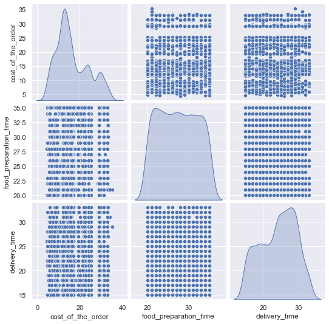

```python
sns.pairplot(df[['cost_of_the_order','rating', 'food_preparation_time', 'delivery_time']], diag_kind="kde")
```

#### Observations:

- Also see question #6 as some of this is repetitive. Note: I like the Pandas Profiling Widget, however it does not print, so I have excluded it by commenting out the code in the begining.
- None of the numerical variables have any strong correlation
  - Delivery_time is correlated with day_of_the_week
- Doesn't make sense to graph 'order_id', 'customer_id' bc they are assigned numbers

### Question 13: Suppose the company wants to provide a promotional offer in the advertisement of the restaurants. The condition to get the offer is that the restaurants must have a rating count of more than 50 and the average rating should be greater than 4. Write the code to find the restaurants fulfilling the criteria to get the promotional offer. (2 marks)

```python
# Recall from step 1 that the ratings is an 'object'
df.info()
```

```
<class 'pandas.core.frame.DataFrame'>
RangeIndex: 1898 entries, 0 to 1897
Data columns (total 9 columns):
 #   Column                 Non-Null Count  Dtype
---  ------                 --------------  -----
 0   order_id               1898 non-null   int64
 1   customer_id            1898 non-null   int64
 2   restaurant_name        1898 non-null   category
 3   cuisine_type           1898 non-null   category
 4   cost_of_the_order      1898 non-null   float64
 5   day_of_the_week        1898 non-null   category
 6   rating                 1898 non-null   object
 7   food_preparation_time  1898 non-null   int64
 8   delivery_time          1898 non-null   int64
dtypes: category(3), float64(1), int64(4), object(1)
memory usage: 102.7+ KB
```

```python
#Replace Not Given w/ 0
df = df.replace(to_replace ='Not given',value = '0')
```

```python
#change Dtype to Numerical
df['rating'] = df.rating.astype('int')
```

```python
#remove rows that have "0" which is "Not given" to get only the orders with ratings.
df_filtered = df[df['rating'] != 0]
```

```python
#Check to see the replacement, conversion, and subsetting worked as expected.
df_filtered.head()
```

|  | order_id | customer_id | restaurant_name | cuisine_type | cost_of_the_order | day_of_the_week | rating | food_preparation_time | delivery_time |
| --- | --- | --- | --- | --- | --- | --- | --- | --- | --- |
| 2 | 1477070 | 66393 | Cafe Habana | Mexican | 12.23 | Weekday | 5 | 23 | 28 |
| 3 | 1477334 | 106968 | Blue Ribbon Fried Chicken | American | 29.20 | Weekend | 3 | 25 | 15 |
| 4 | 1478249 | 76942 | Dirty Bird to Go | American | 11.59 | Weekday | 4 | 25 | 24 |
| 5 | 1477224 | 147468 | Tamarind TriBeCa | Indian | 25.22 | Weekday | 3 | 20 | 24 |
| 7 | 1477859 | 89574 | Barbounia | Mediterranean | 5.97 | Weekday | 3 | 33 | 30 |

```python
# Group resturans by rating in a new df.
rest_count = df_filtered.groupby(['restaurant_name'])['rating'].count().reset_index();
rest_count.head()
```

|  | restaurant_name | rating |
| --- | --- | --- |
| 0 | 'wichcraft | 1 |
| 1 | 12 Chairs | 2 |
| 2 | 5 Napkin Burger | 2 |
| 3 | 67 Burger | 1 |
| 4 | Alidoro | 0 |

```python
# Extracting the restaurants that have more than 50 ratings.

rest_50 = rest_count[rest_count['rating']>50]['restaurant_name'];

rest_50.head()
```

```
20     Blue Ribbon Fried Chicken
21             Blue Ribbon Sushi
136                  Shake Shack
153            The Meatball Shop
Name: restaurant_name, dtype: category
Categories (178, object): [''wichcraft', '12 Chairs', '5 Napkin Burger', '67 Burger', ..., 'brgr', 'da Umberto', 'ilili Restaurant', 'indikitch']
```

```python
# Finding average ratings for each resturant and sorting them out in descending order

# using groupby() and sort_values() on merged data frame


avg_rating = df_filtered.groupby(['restaurant_name'])['rating'].mean().sort_values(ascending=False).reset_index()

avg_rating
```

|  | restaurant_name | rating |
| --- | --- | --- |
| 0 | 'wichcraft | 5.0 |
| 1 | Ravagh Persian Grill | 5.0 |
| 2 | Chola Eclectic Indian Cuisine | 5.0 |
| 3 | Chote Nawab | 5.0 |
| 4 | Junoon | 5.0 |
| ... | ... | ... |
| 173 | Rohm Thai | NaN |
| 174 | Room Service | NaN |
| 175 | Spice Thai | NaN |
| 176 | Tarallucci e Vino Restaurant | NaN |
| 177 | Wa Jeal | NaN |

178 rows × 2 columns

```python
# Extracting restaurant that have more than 50 ratings using in rest_50 and isin() function

avg_rating[avg_rating['restaurant_name'].isin(rest_50)].head()
```

|  | restaurant_name | rating |
| --- | --- | --- |
| 66 | The Meatball Shop | 4.511905 |
| 89 | Blue Ribbon Fried Chicken | 4.328125 |
| 93 | Shake Shack | 4.278195 |
| 101 | Blue Ribbon Sushi | 4.219178 |

#### Observations:

- While Shake Shake is the most popular by orders, if often recieves no rating.
- There are 4 resturants that meet both criteria - The Meatball Shop, Blue Ribbon Fried Chicken, Shake Shake, and Blue Ribbon Sushi.
- The Meatball Shop gets the highest customer rating.

### Question 14: Suppose the company charges the restaurant 25% on the orders having cost greater than 20 dollars and 15% on the orders having cost greater than 5 dollars. Write the code to find the net revenue generated on all the orders given in the dataset. (2 marks)

```python
# SUBSET all the orders based on cost into two groups

# 1) greater than 5 dollars

subset_df5 = df[df['cost_of_the_order'].between(5,20)]
column_sum5 = subset_df5.sum()

#2) greater than 20 dollars
subset_df20 = df[df['cost_of_the_order'] > 20]
column_sum20 = subset_df20.sum()
```

```python
#Incremetnal fee collected (cost to resturant) on the orders having cost greater than 5 dollars
r1 = column_sum5['cost_of_the_order']*.15
print(r1)
```

```
2477.5755000000004
```

```python
#Incremetnal fee collected (cost to resturant) on the orders having cost greater than 20 dollars
r2 = column_sum20['cost_of_the_order']*.25
print(r2)
```

```
3688.7275
```

```python
#Total Incremental Revenue

(r1+r2).sum()
```

```
6166.303
```

```python
#Method 2

def calc_revenue(order_cost:float) -> float:

  calculation = 0.0

  if order_cost > 5.0 and order_cost < 20.0:

        calculation = 0.15 * order_cost

  else:

      if order_cost > 20.0:

        calculation = 0.25 * order_cost

  return calculation



total_revenue = 0.0

total_revenue = pd.Series(

 map(calc_revenue,

    df['cost_of_the_order']

)).sum()

print(total_revenue)
```

```
6166.303
```

#### Observations:

- The combined net revenue across order types is $6166.30.

### Question 15: Suppose the company wants to analyze the total time required to deliver the food. Write the code to find out the percentage of orders that have more than 60 minutes of total delivery time. (2 marks)

Note: The total delivery time is the summation of the food preparation time and delivery time.

```python
# Total time = food_preparation_time+delivery_time

sum_column = df["food_preparation_time"] + df["delivery_time"]
df["col3"] = sum_column
df.describe()
```

|  | order_id | customer_id | cost_of_the_order | rating | food_preparation_time | delivery_time | col3 |
| --- | --- | --- | --- | --- | --- | --- | --- |
| count | 1.898000e+03 | 1898.000000 | 1898.000000 | 1898.000000 | 1898.000000 | 1898.000000 | 1898.000000 |
| mean | 1.477496e+06 | 171168.478398 | 16.498851 | 2.659642 | 27.371970 | 24.161749 | 51.533720 |
| std | 5.480497e+02 | 113698.139743 | 7.483812 | 2.195280 | 4.632481 | 4.972637 | 6.833603 |
| min | 1.476547e+06 | 1311.000000 | 4.470000 | 0.000000 | 20.000000 | 15.000000 | 35.000000 |
| 25% | 1.477021e+06 | 77787.750000 | 12.080000 | 0.000000 | 23.000000 | 20.000000 | 47.000000 |
| 50% | 1.477496e+06 | 128600.000000 | 14.140000 | 4.000000 | 27.000000 | 25.000000 | 52.000000 |
| 75% | 1.477970e+06 | 270525.000000 | 22.297500 | 5.000000 | 31.000000 | 28.000000 | 56.000000 |
| max | 1.478444e+06 | 405334.000000 | 35.410000 | 5.000000 | 35.000000 | 33.000000 | 68.000000 |

```python
# Count the orders that take longer than 60mins to be deleivery from the time the cusotmer enters the order.
subset_df = df[df['col3'] > 60]
column_count = subset_df.count()
print(column_count ['col3'])
```

```
200
```

```python
# The % of rders that take longer than 60mins to be deleivery from the time the cusotmer enters the order.

orders_60mins = (column_count ['col3']) / 1898
print (orders_60mins)
```

```
0.1053740779768177
```

#### Observations:

- 10.5% of the orders take longer than 60mins for the cusotmer to recieve.

### Question 16: Suppose the company wants to analyze the delivery time of the orders on weekdays and weekends. Write the code to find the mean delivery time on weekdays and weekends. Write your observations on the results. (2 marks)

```python
# Do Weekday or Weekend delivery times take longer?

we = df.groupby(['day_of_the_week'])['delivery_time'].mean().reset_index()
print(we)
```

```
  day_of_the_week  delivery_time
0         Weekday      28.340037
1         Weekend      22.470022
```

#### Observations:

The delivery time for weekdays is ~6mins (5.87mins) longer than the weekend

### Conclusion and Recommendations

### **Question 17:** Write the conclusions and business recommendations derived from the analysis. (5 marks)

## FoodHub – Data Analysis & Recommendation

### Objective¶

Understand the demand for different restaurants which will help FoodHub in enhancing their customer experience.

### Data Analysis

As the data is presented:

1. There are 1898 observations (orders placed by the customer).

1.1. The data is of mixed type (5 Numeric Data Types and 4 text strings)

1.1.1. There is no missing data in the DataFrame; some data type changes are required on 3 fields to allow them to be easily included in the analysis.

## Findings

### Customers

1.1. There are 1200 unique customers; some customers have used FoodHub mulitple times

1.2. 34% of the customer base are “repeat” customers; with and average of ~2.5 orders

1.3. Your ‘most repeat order” has used the service 13 times

### Demand

2.1. Weekends are busier than weekdays

2.2. American food is the most popular weekend order followed by Japanese and Italian.

2.2.1. American and Japanese cost_of_the_order is higher than others.

2.3. The average total time from customer order to drop-off is just under an hour (~51 mins).

2.3.1. The average prep time is ~27 mins

2.3.2. The mean delivery time is ~24mins

### Pricing

3.1. The average cost per order is $16.50 across all days.

3.2. The number of orders > $20 is 29% of the total orders.

3.3. The coupon should be sent to the customer with ID 62359. They ordered from Pylos during the week, and had a total bill of $35.41.

3.4 The result of 25percent on orders greater than 20 and 15percent on orders greater than 5 would result in an additonal 6,166.30!

### Restaurants

5.1.1. 178 unique restaurants represented in this data sample.

5.1.2. 14 cuisine types

5.1.3. American food is the most often selected "cuisine' type – Japanese > Italian > Chinese

5.1.3.1. American and Japanese cost_of_the_order is higher than others.

### Popularity

6.1. While Shake Shake is the most popular by orders, if often receives no rating.

6.2. A large number (736) of the total orders are not given ratings.

6.2.2. 4 restaurants that meet both criteria (orders & ratings):

6.2.2.1. The Meatball Shop

6.2.2.2. Blue Ribbon Fried Chicken

6.2.2.3. Shake Shake

6.2.2.4. Blue Ribbon Sushi.

6.2.2.5. The Meatball Shop gets the highest customer rating.

### Recommendations to help the organization improve its business outcomes

7.1. While the change in pricing did result in a net incremetnal revenue, pricing changes should be implemented as a ‘A/B’ tests across more segments. Will your restaurant customers see a direct impact (higher orders due to advertising) and justify the additional cost to them as a ‘positive’.

7.2. Driver availability may be impacting the “delivery time”. If the food is ready for pick-up, but waiting on a driver to arrive, there may be more efficient ways to assign drivers.

7.3. The % of repeat customer’s is low, consider a A/B test based on a lower $$ threshold. More customers receiving certificates/loyalty points to apply to next purchase may drive an increase in repeat customer orders.

7.4. Increase the restaurants by offering a secondary category break-out e.g. American>burgers or American>steak and actively recruit restaurants in those gaps by offering “prime” ad placement for their first month upon signup.